# 第五章 离散时间傅里叶变换

## 冲激列采样

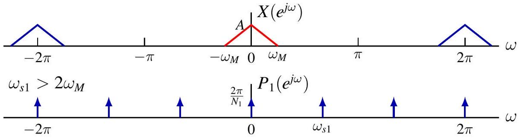

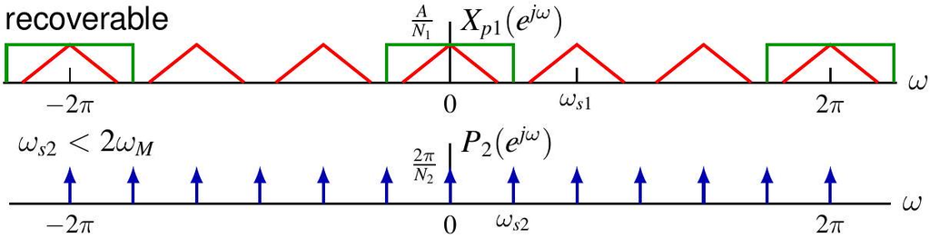

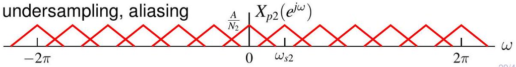

## 离散时间采样定理

Band-limited DT signal $x[n]$ whose spectrum $X\left(e^{j \omega}\right)=0$ for $\omega_{M}<|\omega| \leq \pi$ is uniquely determined by its samples $x[k N], k \in \mathbb{Z}$ if

$$\omega_{s} \triangleq \frac{2 \pi}{N}>2 \omega_{M}$$

Given $\{x[k N]: k \in \mathbb{Z}\}, x[n]$ can be reconstructed as follows

1. construct $x_{p}[n]=\sum_{k=-\infty}^{\infty} x[k N] \delta[n-k N]$
2. send $x_{p}$ through lowpass filter with gain $N$ and cutoff frequency $\omega_{c} \in\left(\omega_{M}, \omega_{s}-\omega_{M}\right)$, i.e.

$$H\left(e^{j \omega}\right)=N\left[u\left(\omega+\omega_{c}\right)-u\left(\omega-\omega_{c}\right)\right]$$

3. output $x_{r}[n]$ with $X_{r}\left(e^{j \omega}\right)=X_{p}\left(e^{j \omega}\right) H\left(e^{j \omega}\right)$ is same as $x[n]$

## 时域重建

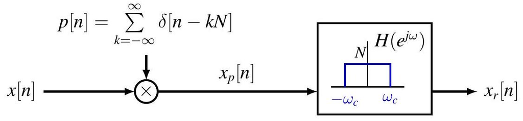

Impulse response of lowpass filter

$$h[n]=\frac{N \sin \left(\omega_{c} n\right)}{\pi n}$$

$x$ recovered by band-limited interpolation using sinc function

$$x[n]=x_{r}[n]=\left(x_{p} * h\right)[n]=\sum_{k=-\infty}^{\infty} x[k N] \frac{N \sin \left(\omega_{c}(n-k N)\right)}{\pi(n-k N)}$$

## 抽取

DT signal $x[n]$

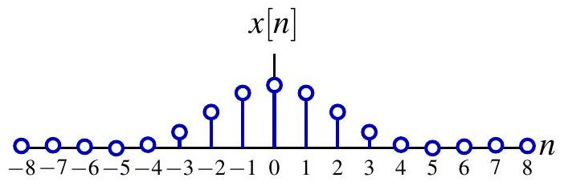

Sampled signal

$$x_{p}[n]=\sum_{k=-\infty}^{\infty} x[k N] \delta[n-k N]$$

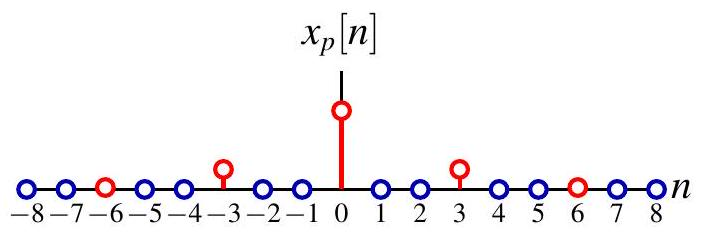

Decimated signal

$$x_{b}[n]=x[n N]$$

Reduces samples

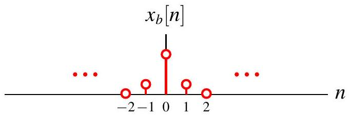

## 抽取

$$\begin{aligned}
X_{b}\left(e^{j \omega}\right) & =\sum_{n \in \mathbb{Z}} x_{b}[n] e^{-j \omega n} \\
& =\sum_{n \in \mathbb{Z}} x[n N] e^{-j \omega n} \\
& =\sum_{k \in N \mathbb{Z}} x[k] e^{-j \omega k / N} \quad(k=n N) \\
& =\sum_{k \in \mathbb{Z}} x_{p}[k] e^{-j \frac{\omega}{N} k} \quad\left(x_{p}[n]=0 \text { for } n \in \mathbb{Z} \backslash N \mathbb{Z}\right) \\
& =X_{p}\left(e^{j \omega / N}\right)
\end{aligned}$$

Recall $X_{p}\left(e^{j \omega}\right)$ has period $2 \pi / N$, so $X_{b}\left(e^{j \omega)}\right.$ has period $2 \pi$. If no aliasing in sampling

- $X_{b}$ is stretched version of $X$ in each period
- $X_{b}\left(e^{j \omega}\right)=X_{p}\left(e^{j \omega / N}\right)$, but $X_{b}\left(e^{j \omega}\right) \neq X\left(e^{j \omega / N}\right)$

## 抽取

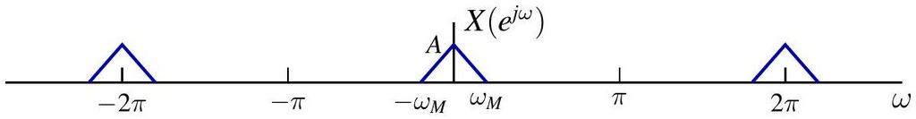

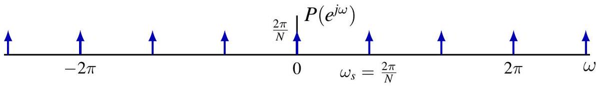

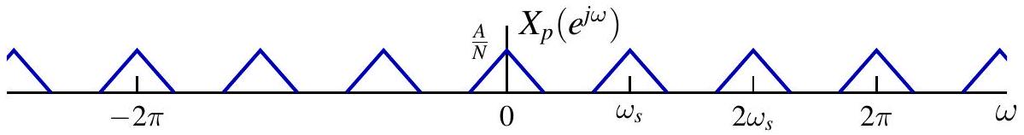

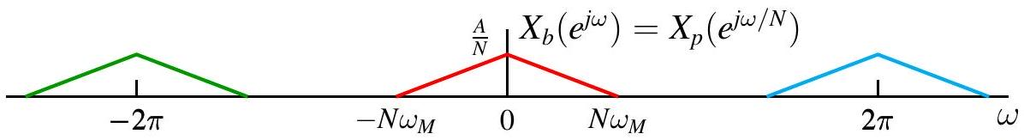

## 目录

1. DTFT 的卷积性质
2. DTFT 的乘积性质
3. 线性常系数差分方程描述的系统
4. 离散时间信号的采样
5. 连续时间信号的离散时间处理

## 连续时间信号的离散时间处理

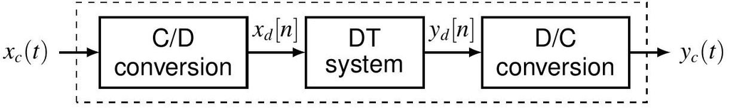

离散时间处理的优点

- versatility of digital electronic devices
- resilience against noise

在实际中

- C/D implemented by analog-to-digital converter
- D/C implemented by digital-to-analog converter

理想化假设

- no quantization
- C/D by impulse-train sampling
- D/C by ideal reconstruction

## 模数转换（C/D）

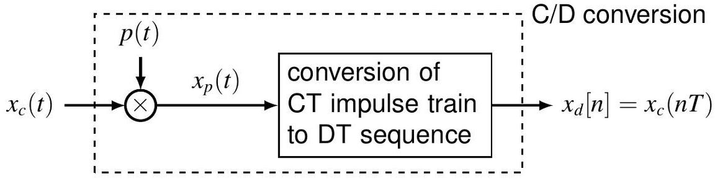

Assumption

- $x_{c}(t)$ bandlimited, e.g. lowpass filtered
- sampling above Nyquist rate, no aliasing

Relation between CT and DT spectra

$$\begin{aligned}
X_{p}(j \omega) & =\mathrm{CTFT}\left\{\sum_{n \in \mathbb{Z}} x_{c}(n T) \delta(t-n T)\right\} \\
& =\sum_{n \in \mathbb{Z}} x_{c}(n T) e^{-j \omega T n}=\sum_{n \in \mathbb{Z}} x_{d}[n] e^{-j \omega T n}=X_{d}\left(e^{j \omega T}\right)
\end{aligned}$$

## 模数转换（C/D）

时域

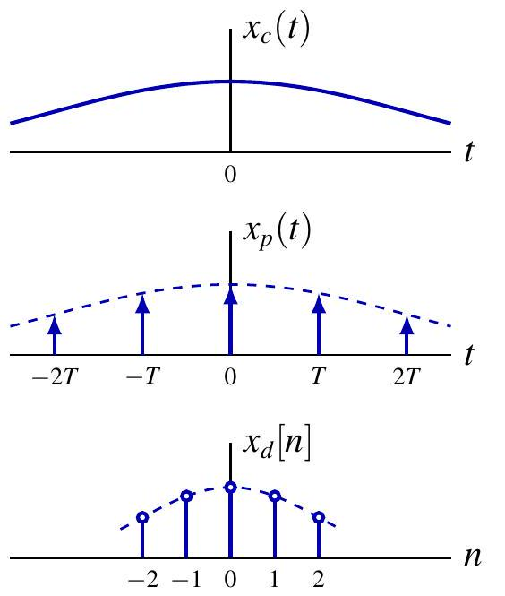

频域

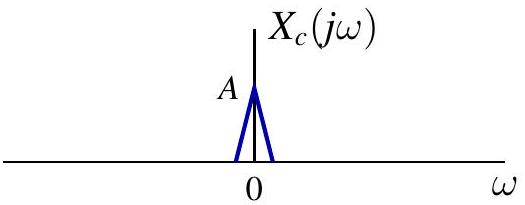

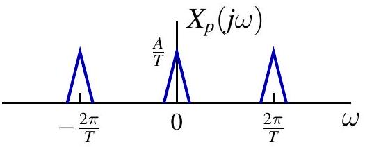

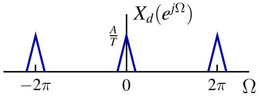

From $x_{p}$ to $x_{d}$ : normalization in both time and frequency

## 数模转换（D/C）

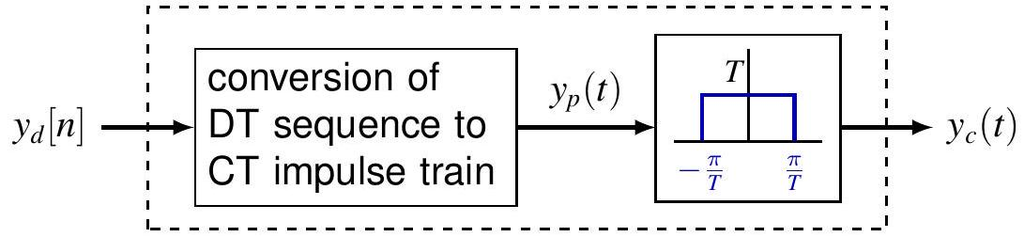

Relation between CT and DT spectra

$$\begin{aligned}
& Y_{p}(j \omega)=Y_{d}\left(e^{j \omega T}\right) \\
& Y_{c}(j \omega)= \begin{cases}Y_{p}(j \omega) & |\omega|<\frac{\omega_{s}}{2}=\frac{\omega}{T} \\
0, & \text { otherwise }\end{cases}
\end{aligned}$$

## 数模转换（D/C）

时域

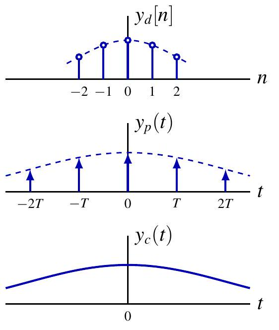

频域

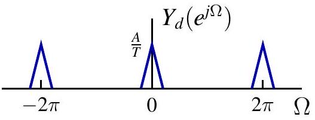

频域

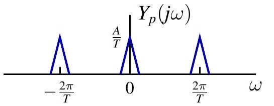

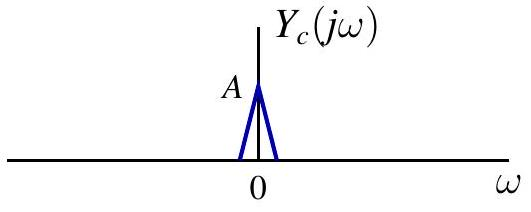

Reverse process of C/D conversion

## 频率响应

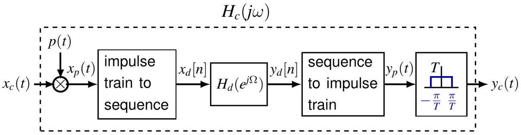

1. $Y_{d}\left(e^{j \Omega}\right)=H_{d}\left(e^{j \Omega}\right) X_{d}\left(e^{j \Omega}\right)$
2. $Y_{p}(j \omega)=Y_{d}\left(e^{j \omega T}\right)=H_{d}\left(e^{j \omega T}\right) X_{d}\left(e^{j \omega T}\right)=H_{d}\left(e^{j \omega T}\right) X_{p}(j \omega)$
3. $Y_{c}(j \omega)=Y_{p}(j \omega) H_{\mathrm{lp}}(j \omega)=H_{d}\left(e^{j \omega T}\right) X_{p}(j \omega) H_{\mathrm{lp}}(j \omega)=H_{d}\left(e^{j \omega T}\right) X_{c}(j \omega)$
4. $H_{c}(j \omega)= \begin{cases}H_{d}\left(e^{j \omega T}\right) & |\omega|<\frac{\omega_{s}}{2}=\frac{\omega}{T} \\ 0, & \text { otherwise }\end{cases}$

频率响应

$$\begin{gathered}
H_{c}(j \omega)= \begin{cases}H_{d}\left(e^{j \omega T}\right) & |\omega|<\frac{\omega_{s}}{2}=\frac{\omega}{T} \\
0, & \text { otherwise }\end{cases} \\
\Longrightarrow H_{d}\left(e^{j \Omega}\right)=H_{c}\left(j \frac{\Omega}{T}\right),|\Omega|<\pi
\end{gathered}$$

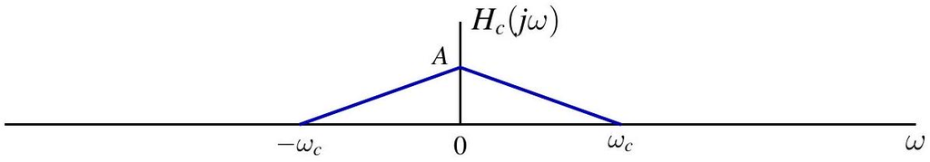

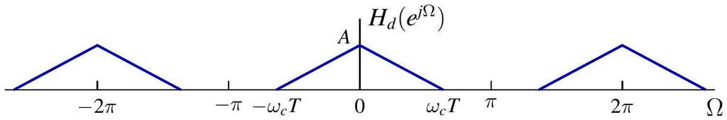

## 例: 数字微分器

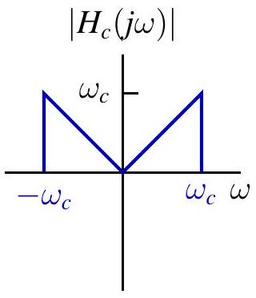

$$\arg H_{c}(j \omega)$$

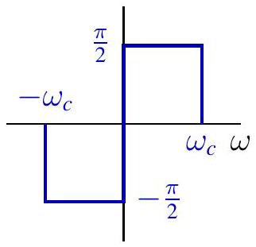

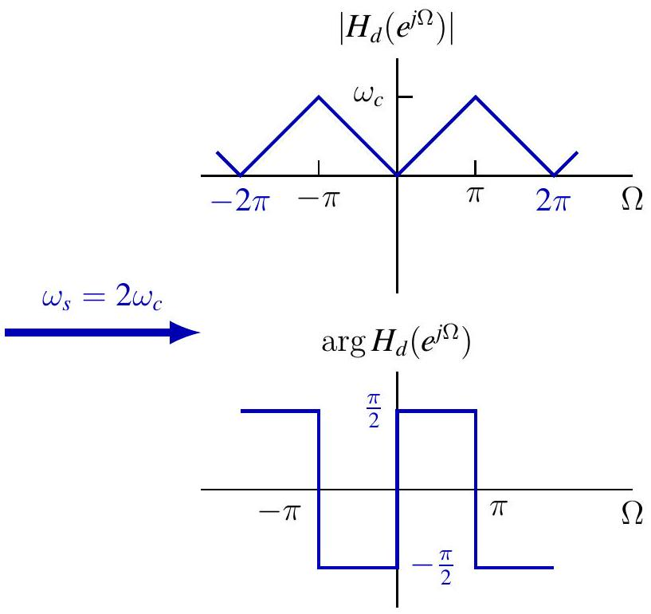

## 作业

# 第五章 离散时间傅里叶变换 完